# COMM Consult validation data

- Show All Code
- Hide All Code
- View Source

Sampling texts for human coding

Author

[Christian Rauh](http://www.christian-rauh.eu)

Published

September 11, 2025

# Purpose and setup

We need to validate our text-based measures for ‘information quality’ of consultation responses against the assessments of human coders.

Coding full texts is not possible - text length varies drastically and can span several pages of text. We thus agreed to let them code **shorter units (3-4 sentences)**. As we have no consistent formatting markers in the text data (such as paragraphs or line breaks), we decided to take the first few sentences of each contribution (typically containing the key messages) of individual consultation responses. In this context, we want to exclude the first sentence, as this often just informs about who the commenter is.

We are able to hire three human coders who can code around ~ 600 units (based on testing coding for units of 3-4 sentences length). We want to assess intercoder reliability as well, requiring us to generate an overlap sample seen by all coders, meaning that the targeted samples are the following:

- One ‘overlap’ sample of 100 text snippets (contained in all sets)
- Three separate/distinct samples of 500 text snippets (one for each coder)

For each coder, these samples should cover the full breadth/variation of the text measures we want to validate, while also keeping the policy stage of the respective consultation balanced as this is the main analytic distinction in the manuscript.

Accordingly, my work plan is as follows:

1. Load full text data and extract text snippets
2. (Re-) Calculate text measures for the snippets
3. Draw the four stratified random samples (avoid duplicates across samples to maximize number of obs)
4. Build and store three samples to be fed into the coding app (unique id, keep measured values, mark overlap obs)

All code is also available on **[GitHub](https://github.com/ChRauh/CONSULT-ValidationApps)**.

The R packages used for this exercise:

**Show R code**

```r
# Packages used #####
library(tidyverse) # Easily Install and Load the 'Tidyverse' CRAN v2.0.0
library(purrr) # Functional Programming Tools CRAN v1.0.4
library(tokenizers) # Fast, Consistent Tokenization of Natural Language Text CRAN v0.3.0
library(quanteda) # Quantitative Analysis of Textual Data CRAN v4.3.1
library(cld2) # Google's Compact Language Detector 2 CRAN v1.2.6
library(textclean) # Text Cleaning Tools CRAN v0.9.3
library(spacyr) # Wrapper to the 'spaCy' 'NLP' Library CRAN v1.3.0
library(sophistication) # https://github.com/kbenoit/sophistication
library(patchwork) # The Composer of Plots CRAN v1.3.0
```

# Load and prepare feedback data

- I use the latest data file from Dropbox
- Dropping all observations with empty *`text_full`* observations

**Show R code**

```r
# Using absolute path for now (Dropbox, WZB office machine)
fbs <- read_rds("C:/Users/rauh/Dropbox/CR data/CommConsultText/Data/FeedbackTextData-Complete_new.rds")

# Select vars and calculated measures on full text level
# N.B.: 'feedback_ref' is a unique id
fbs <- fbs %>%
  filter(!text_full == " ") %>% # Drop observations without full text
  select(c(feedback_ref, policy_stage_short, text_full, n_sentence, starts_with("ne_"), flesch, legalese, entropy)) %>%
  rowwise() %>%
  mutate(entities = sum(c_across(starts_with("ne_")), na.rm = TRUE)) %>% # Sum all named entities in text
  ungroup()

fbs <- fbs %>%
  select(-c(starts_with("ne_"))) %>% # Drop individual entity counts
  mutate(entities =  entities/n_sentence) # Normalize NE sum to text length
```

# Extraction of text snippets

I took a **couple of choices here**:

- Remove the first sentence of the comment - but only if overall comment is more than two sentences long
- We want the human coders to see meaningful text (= full sentences), while avoiding overly long comments and preventing too much variation in the length of the snippets coders get to see: I selected **anything up to the sentence that contains the 200th word**.

**Show R code**

```r
# Extract text snippets for coding ####

# Helper function
# The first sentence almost always introduces the sender of the feedback - we do not want this in the data the humans will see
# But we also have a number of shorter feedback which we do not want to artificially reduce too much
# Thus we remove the first sentence only when the overall comment is more than 2 sentences long
remove_first_if_long <- function(text) {
  sents <- tokenize_sentences(text, simplify = TRUE)
  if (length(sents) > 2) {
    sents <- sents[-1]  # drop first
  }
  paste(sents, collapse = " ") |> str_squish()
}


# Helper function
# We want the human coders to see meaningful text (= full sentences), while avoid overly long comments
# and having too much variation in the length of the snippets coders get to see.
# Thus the function returns the shortest number of sentences around 200 words
# = completing the text with the sentence that contains the 200th word)
snippet_by_words <- function(text, target = 200) {
  sents <- tokenize_sentences(text, simplify = TRUE)
  if (length(sents) == 0L) return(NA_character_)
  wc <- count_words(sents)
  idx <- which(cumsum(wc) >= target)[1]           # first sentence that passes target
  if (is.na(idx)) idx <- length(sents)            # text shorter than target → whole text
  paste(sents[seq_len(idx)], collapse = " ") |> str_squish()
}


# Apply both of the above logics to the consultation text (takes some time ...)
fbs <- fbs %>%
  mutate(
    text_mod = map_chr(text_full, remove_first_if_long),
    snippet  = map_chr(text_mod, snippet_by_words, target = 200)
  ) %>%
  select(-text_mod)

# Word count of resulting snippets
fbs$snippet_wc <- count_words(fbs$snippet)
hist(fbs$snippet_wc)
summary(fbs$snippet_wc)

# Inspect unusually long snippets
test <- fbs %>% filter(snippet_wc > 300)

i <- sample(nrow(test), 1)
test$snippet[i]

sents <- tokenize_sentences(test$snippet[i], simplify = TRUE)
sents

# Many correct cases (with awkward sentences ;)),
# but also a few that are off because list items or annex tables are not properly detected as separate sentences
rm(test)


# For the sake of human coder sanity, I drop the 224 observations with snippets longer than 300 words
fbs <- fbs %>% filter(snippet_wc <= 300)


# Finally, we do not want to have duplicated snippet texts in the final coder samples
# N.B. concerted campaigns!
sum(duplicated(fbs$snippet))
duplictes <- fbs %>% filter(duplicated(snippet))
fbs <- fbs %>% mutate(dupl = duplicated(snippet)) %>% filter(!dupl) %>% select(-dupl)


# Random example inspection
# Kable an example table here in the qmd

i <- sample(nrow(fbs), 1)
fbs$snippet[i]
fbs$snippet_wc[i]

# Intermediary saving
write_rds(fbs, "./data/snippets.rds")
```

Have a look at how long (number of words) the extracted snippets are:

**Show R code**

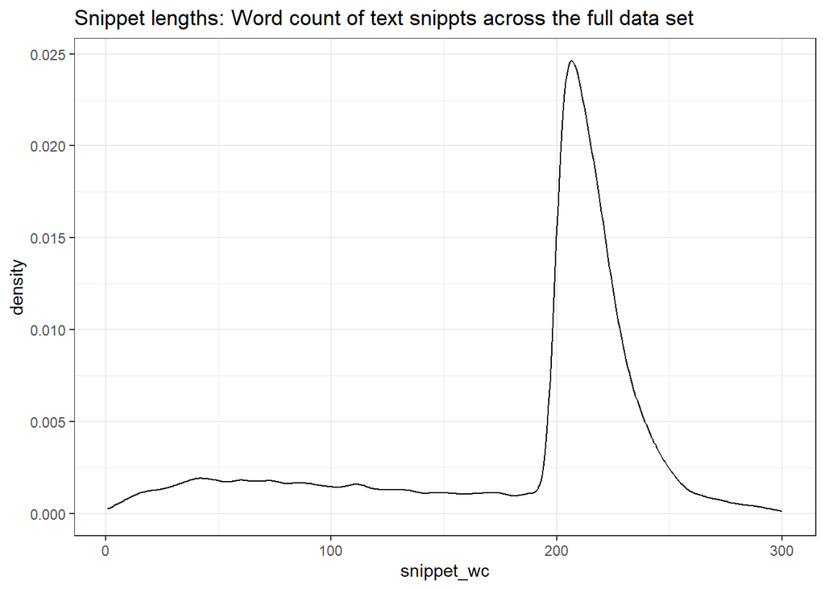

```r
library(tidyverse)
read_rds("./data/snippets.rds") %>%
  ggplot(aes(x = snippet_wc))+
  geom_density()+
  labs(title = "Snippet lengths: Word count of text snippts across the full data set")+
  theme_bw()
```

By construction, they cluster around the cutoff criterion of 200 words (or higher, for commenters using long sentences). But we also have a couple of (much) shorter ones in cases when commenters actually supplied (significantly) less than 200 words.

While ultra-short observations should be probably excluded from human coding (see below), I think **we should allow some variation in this regard** (as these are real cases). The alternative would be to select only cases that have at least 200 words, then the coder samples would be more balanced regarding length.

# Calculate ‘information quality’ for snippets

Then I extracted all the text-based measures we use in the full text analysis also for the short snippets (following the original code ). These data allow us later to offer the coders with texts that also vary sufficiently across the measures we want to validate.

**Show R code**

```r
# Calculate text based measures for the snippets ####


# Quanteda corpus object of the snippet texts
qcorp <- corpus(fbs$snippet, docvars = data.frame(fbs[, c("feedback_ref")]))
docids <- docvars(qcorp) %>%
  mutate(doc_id = as.character(docid(qcorp)))



# Flesch Reading Ease Score, based on sophistication package

re <- covars_make(qcorp, readability_measure = "Flesch")
re$doc_id <- paste0("text",rownames(re))

readability <- merge(docids[ ,c("doc_id", "feedback_ref")],
                    re[, c("doc_id", "meanSentenceLength", "Flesch")],
                    by = "doc_id", all.x = T) %>%
  rename(snippet_flesch = Flesch,
         snippet_meanSentenceLength = meanSentenceLength) %>%
  select(-doc_id)

fbs <- fbs %>%
  left_join(readability, by = "feedback_ref")



# Named entity counts

ent <- spacy_extract_entity(qcorp, output = "data.frame", type = "all") # Extraction (takes some time)

ent <- ent %>% # Join in doc_ids
  left_join(docids,
            by = "doc_id") %>%
  select(c(feedback_ref, ent_type, text))

# Summarize: Count number of entity type by each feedback text
# N.B.: if the respective text didn't contain any NE it is not in the data
# respectively missing values in the assembled data set need to be filled with zeros
ent2 <-
  ent %>%
  select(-text) %>% # The entity text
  group_by(feedback_ref) %>%
  count(across(everything())) %>%
  pivot_wider(id_cols = "feedback_ref", names_from = "ent_type", values_from = "n", values_fill = 0)

names(ent2)[2:ncol(ent2)] <- paste0("NE_", names(ent2)[2:ncol(ent2)]) %>% tolower() # Clarify names

entities <- ent2 %>%
  rowwise() %>%
  mutate(snippet_ne_sum = sum(c_across(starts_with("ne_")), na.rm = TRUE)) %>%
  ungroup() %>%
  select(c(feedback_ref, snippet_ne_sum))

# Add to target data - and ensure that missing values are set to zero (cf. above)
fbs <- fbs %>%
  left_join(entities, by = "feedback_ref") %>%
  mutate(across(.cols = starts_with("snippet_ne_"), function(x){ifelse(is.na(x), 0, x)}))


# Part-of-speech distributions (sophistication/spacyr) - to get the number of sentences as in main analyses
# Puts out doc_id itself, order not necessarily correct
pos <- covars_make_pos(qcorp)

pos2 <- pos %>% # Join in doc_ids
  left_join(docids,
            by = "doc_id") %>%
  select(-doc_id)

fbs <- fbs %>%
  left_join(pos2 %>%
              select(c(feedback_ref, n_sentence)) %>%
              rename(snippet_n_sentence = n_sentence),
            by = "feedback_ref")

fbs$snippet_entities <- fbs$snippet_ne_sum/fbs$snippet_n_sentence # Normalize entity count to text length


# Legalese (dictionary)

legalese <- read_rds("C:/Users/rauh/Dropbox/CR data/CommConsultText/Data/EU_Legalese_Dict.rds")
legalese.r <- paste(legalese$token, collapse = "|")
fbs$snippet_legalese <- str_count(tolower(fbs$snippet), legalese.r)/fbs$snippet_wc # relative frequency of words from legalese dictionary in text
hist(fbs$snippet_legalese)

test <- fbs %>% filter(snippet_legalese >= .5)
# remove ultra short snippets! XXX


# Entropy

# Quanteda stopword list as RegEx
stops <- paste(stopwords("english"), collapse = " | ")
stops <- paste(" ", stops, " ", sep = "")

# Prepare the text bits
fbs$snippet_entropytext <- tolower(fbs$snippet) # Lower case
fbs$snippet_entropytext <- gsub(stops, " ", fbs$snippet_entropytext, fixed = F) # remove stopwords

# Calculate entropy per feedback snippet
fbs$snippet_entropy <- NA
progress_bar = txtProgressBar(min=0, max=nrow(fbs), style = 3, char="=")
for (i in 1:nrow(fbs)) {
  text <- tokens(fbs$snippet_entropytext[i], remove_numbers = T, remove_punct = T, remove_symbols = T, remove_separators = T) # tokenize EU references with some preprocessing
  text <- as.character(text) # character vector of each individual token
  if(length(text) == 0){next}
  freqs <- table(text)/length(text) # relative token frequency
  fbs$snippet_entropy[i] <- -sum(freqs * log2(freqs)) # entropy formula following Katz/Bommarito II (2014)
  setTxtProgressBar(progress_bar, value = i) # Progress indicator
}
close(progress_bar)
```

Let’s quickly compare the distribution of our four information quality measures in the snippets to that observed in the full feedback texts:

**Show R code**

```r
# Compare distribution of text measures between full text and snippets ####


# Helper function for distribution comparison
plot_density_compare <- function(data, var1, var2) {
  # capture the variable names
  var1 <- rlang::ensym(var1)
  var2 <- rlang::ensym(var2)

  data_long <- data %>%
    select(!!var1, !!var2) %>%
    pivot_longer(cols = everything(),
                 names_to = "variable",
                 values_to = "value")

  ggplot(data_long, aes(x = value, fill = variable, color = variable)) +
    geom_density(alpha = 0.3) +
    theme_minimal() +
    labs(x = "Value", y = "Density",
         title = paste(rlang::as_name(var1), "vs.", rlang::as_name(var2)))+
    theme(legend.position = "bottom",
          plot.title = element_text(hjust = 0.5))
}

# Compare vars
p1 <- plot_density_compare(fbs, entropy, snippet_entropy)
p2 <- plot_density_compare(fbs, flesch, snippet_flesch)
p3 <- plot_density_compare(fbs, entities, snippet_entities)
p4 <- plot_density_compare(fbs, legalese, snippet_legalese)

# Plot comparison
(p1+p2) / (p3+p4) +
  plot_annotation(
    title = "Comparing the distribution of 'information quality' measures\nacross full texts and shorter snippets for coding"
  ) &
  theme(plot.title = element_text(hjust = 0.5))  # center the title


ggsave(
  filename = "./plots/TextMeasuresFullVsSnippets.png",
  width = 30, height = 25, units = "cm", dpi = 300
)


# Entropy is an issue (shorter text, less potental for variable vocabulary - probably also an issue for the analyses?)
# Entities is also somewhat smaller for shorter text, but ample variation ...




# Save the snippet information to disc ####

snips <- fbs %>% select(c(feedback_ref, policy_stage_short, starts_with("snippet")))
write_rds(snips, "./data/snippets_indicators.rds")
snips <- read_rds("./data/snippets_indicators.rds")
```

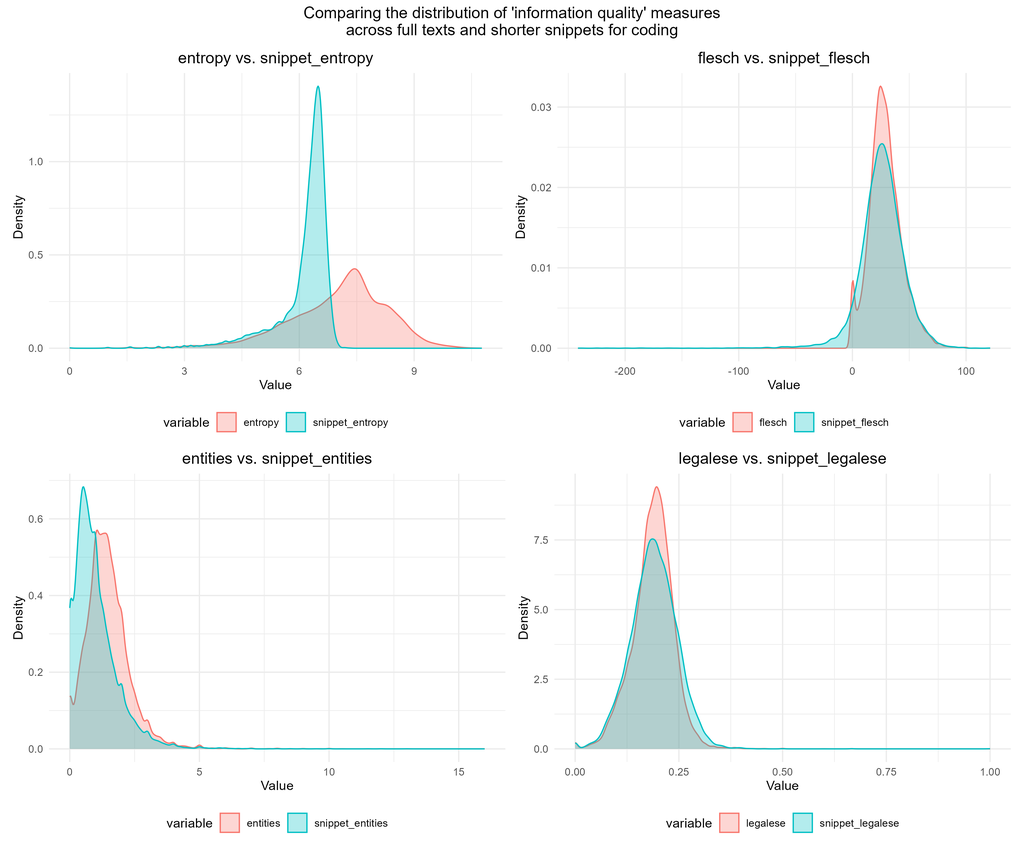

Looks largely reasonable, with a few notable points:

- **Entropy** differs strongly and is more constrained for the shorter snippets - somehow logical as shorter text limit the diversity of the vocabularly one can use. Still sufficient variation in the snippets for validation, but one should think about normalization in the main analysis (as we probably capture text length implicitly).
- Fewer **entities** in the snippets - also reasonable with regard to text length and considering that we only look at the first few sentences. But also sufficient variation on offer for validation.
- **Flesch** readability measure not capped as in the main analysis, done for the sampe below.

# Draw coder samples

Clean up the data on the *population* to draw from a little further along the above observations:

- Keep only snippet based information
- **Remove extremely short observations (< than 10 words)**
- Clean up encoding errors in the raw texts (**should be done in main analyses as well!**)

**Show R code**

```r
# Prepare population data
pop <- snips %>%
  select(feedback_ref, snippet, policy_stage_short, snippet_wc, snippet_entropy, snippet_flesch, snippet_entities, snippet_legalese) %>%
  rename(id = feedback_ref,
         text = snippet,
         stage = policy_stage_short)
names(pop) <- names(pop) %>% str_remove("snippet_")


# Filter population data

pop <- pop %>%
  mutate(lang = detect_language(text)) %>%
  filter(lang == "en") %>%
  select(-lang) %>%
  filter(wc > 10) %>% # A.o. removes extreme legalese cases
  mutate(flesch = ifelse(flesch < 0, 0, flesch), # Cap Flesch measures as in analysis (and to avoid oversampling of extreme cases)
         flesch = ifelse(flesch > 100, 100, flesch)) %>%
  mutate(text = iconv(text, from = "latin1", to = "UTF-8"),
         text = textclean::replace_non_ascii(text)) # Tackle (some) encoding issues - SHOULD BE DONE IN MAIN ANALYSES AS WELL!
```

Now for the tricky part - **random stratified samples of snippets such that**:

- the full variation of our text measures is seen by each coder
- each coder gets a sample balanced as to the policy stage of the consultation (n = 500)
- we have an overlap of n = 100 snippets across all three coders to study human reliability
- avoid any other text duplicates in the data

**Show R code**

```r
# Sampling
# Reminder: Each coder should see 500 units that cover variation across all measures and balances the policy stages
# Overlap sample of 100 obs with the same features

# - > stratified sampling

set.seed(20250911)  # for reproducibility


# Mark quintile bins for the the text measures + stratum ids (including stage)

pop_binned <- pop %>%
  mutate(
    q_entropy  = ntile(`entropy`,  5),
    q_flesch   = ntile(`flesch`,   5),
    q_entities = ntile(`entities`, 5),
    q_legalese = ntile(`legalese`, 5),
    strata = interaction(stage, q_entropy, q_flesch, q_entities, q_legalese, drop = TRUE)
  )


# Stratum fill function
# proportional integer allocation within a stage
# Given available counts per stratum (s), and a target size m,
# allocate integers n_i with:
#   - proportional to size,
#   - capped by availability,
#   - remainder distributed by largest fractional parts,
#   - if caps reduce total, re-distribute to strata with remaining capacity

alloc_counts <- function(s, m) {
  if (sum(s) == 0 || m <= 0) return(rep(0L, length(s)))
  # initial proportional allocation
  p <- s / sum(s)
  raw <- m * p
  n <- pmin(s, floor(raw))
  # distribute remainder by largest fractional part (Hamilton method)
  rem <- m - sum(n)
  if (rem > 0) {
    frac <- raw - floor(raw)
    # prefer strata with capacity left
    cap_left <- s - n
    frac[cap_left <= 0] <- -Inf
    if (any(is.finite(frac))) {
      add_ix <- order(frac, decreasing = TRUE)[seq_len(min(rem, sum(is.finite(frac))))]
      n[add_ix] <- n[add_ix] + 1L
    }
  }
  # if caps caused under-allocation, top up randomly among strata with capacity
  deficit <- m - sum(n)
  if (deficit > 0) {
    cap_left <- s - n
    pool <- which(cap_left > 0)
    if (length(pool) > 0) {
      # sample proportional to remaining capacity
      probs <- cap_left[pool] / sum(cap_left[pool])
      extra <- sample(pool, size = deficit, replace = FALSE, prob = probs)
      tab <- table(extra)
      n[as.integer(names(tab))] <- n[as.integer(names(tab))] + as.integer(tab)
    }
  }
  n
}


# Sampling function  within one stage, spreading across multi-way strata of the text measure values
sample_one_stage <- function(df_stage, m) {
  if (nrow(df_stage) == 0L || m <= 0L) return(df_stage[0, ])

  # counts per composite stratum (within this stage)
  strata_counts <- df_stage %>%
    dplyr::count(strata, name = "s")

  # integer allocation per stratum (proportional, capped by availability)
  strata_counts <- strata_counts %>%
    dplyr::mutate(n_take = alloc_counts(s, m)) %>%
    dplyr::filter(n_take > 0L)

  # join plan, randomize within stratum, then keep first n_take rows per stratum
  df_stage %>%
    dplyr::inner_join(strata_counts, by = "strata") %>%
    dplyr::group_by(strata) %>%
    dplyr::mutate(.rand = runif(dplyr::n())) %>%
    dplyr::arrange(.rand, .by_group = TRUE) %>%
    dplyr::mutate(.rn = dplyr::row_number()) %>%
    dplyr::filter(.rn <= dplyr::first(n_take)) %>%  # <- varies by group: OK in filter()
    dplyr::ungroup() %>%
    dplyr::select(-.rand, -.rn, -s, -n_take)
}


# Function: build one full sample with ~equal stage balance
take_one_sample <- function(df_remaining, total_n) {
  # target per stage ~ equal split
  stages <- df_remaining %>% count(stage, name = "avail")
  # split total_n as evenly as possible across the 3 stages, favoring stages with availability
  base <- floor(total_n / 3)
  rem  <- total_n - base * 3
  # distribute the remainder to the stages with most available rows
  add <- rep(0L, nrow(stages))
  if (rem > 0) {
    add_ix <- order(stages$avail, decreasing = TRUE)[seq_len(rem)]
    add[add_ix] <- 1L
  }
  targets <- pmin(stages$avail, base + add)
  plan <- tibble(stage = stages$stage, target = targets)

  # sample within each stage using multi-way strata
  sampled <- map2_dfr(
    plan$stage, plan$target,
    ~ df_remaining %>%
      filter(stage == .x) %>%
      sample_one_stage(m = .y)
  )

  # If this falls short of the target (e.g., not enough availability in some strata/stages),
  # top up from the remaining rows while preserving stage balance as far as possible.
  short <- total_n - nrow(sampled)
  if (short > 0) {
    pool <- anti_join(df_remaining, sampled, by = "id")
    # gentle bias toward under-represented stages in the current sample
    have <- sampled %>% count(stage, name = "have")
    want <- plan %>% left_join(have, by = "stage") %>% mutate(have = replace_na(have, 0L),
                                                              gap = pmax(target - have, 0L))
    pool <- pool %>% left_join(want %>% select(stage, gap), by = "stage")
    # weight by (1 + gap) to favor stages needing top-up
    probs <- (pool$gap + 1) / sum(pool$gap + 1)
    extra_idx <- sample(seq_len(nrow(pool)), size = short, replace = FALSE, prob = probs)
    sampled <- bind_rows(sampled, pool[extra_idx, ])
  }
  sampled
}


# Build four non-overlapping samples (100, 500, 500, 500)

sizes <- c(100L, 500L, 500L, 500L)

samples <- vector("list", length(sizes))
remaining <- pop_binned

for (i in seq_along(sizes)) {
  samp_i <- take_one_sample(remaining, sizes[i])
  samples[[i]] <- samp_i
  remaining <- anti_join(remaining, samp_i, by = "id")  # ensure no overlap
}

samp1 <- samples[[1]]  # 100 rows
samp2 <- samples[[2]]  # 500 rows
samp3 <- samples[[3]]  # 500 rows
samp4 <- samples[[4]]  # 500 rows
```

# Check sample properties

To check whether stratified sampling has worked as planned, we can compare the distribution of our four text measures in the snippet population to that in each of the four samples (sample 1 is the smaller overlap sample for intercoder reliability):

**Show R code**

```r
# Quick checks:
lapply(list(samp1, samp2, samp3, samp4), \(x) count(x, stage) %>% mutate(p = n/sum(n)))
lapply(list(samp1, samp2, samp3, samp4), \(x)
       x %>% count(q_entropy, q_flesch, q_entities, q_legalese) %>% summarise(nonempty = sum(n > 0)))




# Visual comparison of the samples and the population ####

# Function to reshape the different data sets for ggplot
to_long <- function(df, src) {
  df %>%
    transmute(
      source  = src,
      entropy = `entropy`,
      flesch  = `flesch`,
      entities= `entities`,
      legalese= `legalese`
    ) %>%
    pivot_longer(cols = entropy:legalese, names_to = "metric", values_to = "value")
}

# Stacking the samples and population
all_long <- bind_rows(
  to_long(pop,   "Population"),
  to_long(samp1, "Sample 1 (overlap, n = 100)"),
  to_long(samp2, "Sample 2 (n= 500)"),
  to_long(samp3, "Sample 3 (n= 500)"),
  to_long(samp4, "Sample 4 (n= 500)")
) %>%
  mutate(
    metric = factor(metric, levels = c("entropy","flesch","entities","legalese")),
    source = factor(source, levels = c("Population","Sample 1 (overlap, n = 100)","Sample 2 (n= 500)","Sample 3 (n= 500)","Sample 4 (n= 500)"))
  )

# Plot comparison
ggplot() +
  # population baseline (black line, no fill)
  geom_density(
    data = filter(all_long, source == "Population"),
    aes(x = value),
    linewidth = 2, color = "black"
  ) +
  # samples (transparent fills)
  geom_density(
    data = filter(all_long, source != "Population"),
    aes(x = value, fill = source),
    color = NA,
    alpha = 0.35
  ) +
  facet_wrap(~ metric, scales = "free", ncol = 2) +
  labs(
    x = NULL, y = "Density",
    fill = NULL,
    title = "Distribution of the text measures in snippet population and coder samples",
    subtitle = "Population shown as black outline; samples mark by fill color"
  ) +
  theme_bw(base_size = 12) +
  theme(panel.grid.minor = element_blank(),
        strip.text = element_text(face = "bold.italic"))

ggsave(
  filename = "./plots/MeasureDistributionInCoderSamples.png",
  width = 30, height = 25, units = "cm", dpi = 300
)
```

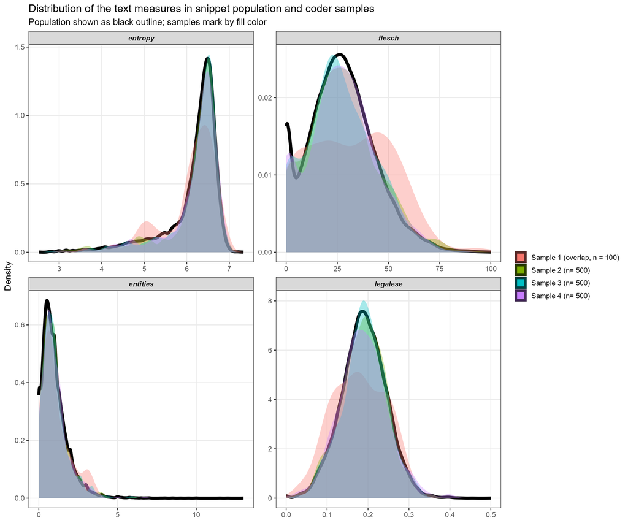

The n=100 overlap sample is a bit more off than the three n= 500 larger samples, but that doens’t matter for our validation. **All in all, the samples for the human coders reflect the distribution in the full population rather well.**  
Then check, whether this also holds regarding the demanded **balance across policy stages**:

**Show R code**

```r
# Visualize distribution across policy stages

tag_stage <- function(df, src) df %>% transmute(source = src, stage)

pop_vs_samples <- bind_rows(
  tag_stage(pop,   "Population"),
  tag_stage(samp1, "Sample 1"),
  tag_stage(samp2, "Sample 2"),
  tag_stage(samp3, "Sample 3"),
  tag_stage(samp4, "Sample 4")
) %>%
  mutate(source = factor(source, levels = c("Population","Sample 1","Sample 2","Sample 3","Sample 4")))


counts <-
  pop_vs_samples %>%
  count(source, stage, name = "n") %>%
  group_by(source) %>%
  mutate(prop = n / sum(n)) %>%
  ungroup()


ggplot(counts, aes(x = stage, y = prop, fill = source)) +
  geom_col(position = position_dodge(width = 0.8), width = 0.7, color = NA) +
  scale_y_continuous(labels = scales::percent_format()) +
  scale_fill_manual(
    values = c(
      "Population" = "grey30",          # dark grey
      "Sample 1"  = "#1b9e77",          # teal-green
      "Sample 2"  = "#d95f02",          # orange
      "Sample 3"  = "#7570b3",          # purple
      "Sample 4"  = "#e7298a"           # magenta
    )
  ) +
  labs(x = NULL, y = "Share of observations\n", fill = NULL,
       title = "Distribution of policy stages in population and coder samples") +
  theme_bw(base_size = 12) +
  theme(legend.position = "bottom")

ggsave(
  filename = "./plots/PolicyStagesInCoderSamples.png",
  width = 30, height = 12, units = "cm", dpi = 300
)
```

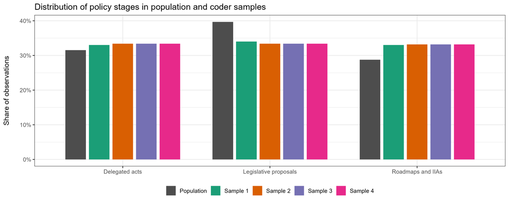

Good, almost perfectly balanced in each of the samples (while legislative proposal feedback is somewhat overrepresented in the full feedback data).

Qualitative perspective - some **random sample snippets** of the type the coders will see:

**Show R code**

```r
library(tidyverse)
library(kableExtra)
read_rds("./data/snippets.rds") %>%
  select(snippet) %>%
  slice_sample(n = 10) %>%
  kable()
```

| snippet |
| --- |
| The partnership should put its main focus on standardization activities along the whole value chains for the ‘industrial internet of things’ and for ‘connected, automated and electric vehicles”. Time-… |
| Applia is happy to contribute to the legislative process with further details at a later stage. 1 - improved coherence with new legislative framework the gpsr is thought as a “safety net” to union har… |
| Further cooperation with gas network operators should be also highlighted, including hydrogen, to ensure a wider integration across energy carriers and their most cost-effective use. Due to increasing… |
| With this comment we want to highlight some important aspects that should not be underestimated. 1. The importance of having a circular resource management perspectivemanaging the use and impacts of r… |
| I don’t want more foreign cultures in my country, which i feed through with my work and taxes. It’s enough what they allow themselves in brussels with germany. |
| Recently it has also been possible to see wealthy people or former politicians who escaped the penalties that would correspond to them, while other people went to prison or suffered trials because of … |
| In fact, administrative burdens have increased as a result of the rfd. The wsc concurs that remedial action is necessary, and continues to encourage that the most cost effective and immediate implemen… |
| We are in favor of postponing the notification deadline for mixtures intended for consumer use by at least one year. Indeed, this additional period of time seems essential to:- finalize the implementa… |
| For many years we have been developing new rose varieties. Breeding roses is a time and resource-consuming process. It is difficult to improve varieties, also because it takes a lot of time to cross-b… |
| Affordable access to essential health solutions to prevent, diagnose, and treat infectious diseases plays a crucial role in preventing or mitigating outbreaks. Although ebola vaccine candidates were i… |

# Final coder samples

Now I combine each of the n=500 samples with the n=100 overlap sample (marked in the data), shuffle the rows in each, and export them as csv files that are later used as input for the coding app.

**Show R code**

```r
# Finalize and export coder samples ####
# Combine coder samples (2-4) with (marked) overlap sample, shuffle rows, and write to csv as required by shiny app

coder1 <-
  rbind(samp1 %>% select(id, text, entropy, legalese, entities, flesch) %>% mutate(overlap = T),
                samp2 %>% select(id, text, entropy, legalese, entities, flesch) %>% mutate(overlap = F)) %>%
  slice_sample(prop = 1) # Shuffle rows

coder2 <-
  rbind(samp1 %>% select(id, text, entropy, legalese, entities, flesch) %>% mutate(overlap = T),
        samp3 %>% select(id, text, entropy, legalese, entities, flesch) %>% mutate(overlap = F)) %>%
  slice_sample(prop = 1) # Shuffle rows

coder3 <-
  rbind(samp1 %>% select(id, text, entropy, legalese, entities, flesch) %>% mutate(overlap = T),
        samp4 %>% select(id, text, entropy, legalese, entities, flesch) %>% mutate(overlap = F)) %>%
  slice_sample(prop = 1) # Shuffle rows



coder1 %>%
  write.csv("./coder_samples/coder1texts.csv",
          row.names = FALSE,    # don’t add row numbers
          quote = TRUE)

coder2 %>%
  write.csv("./coder_samples/coder2texts.csv",
            row.names = FALSE,    # don’t add row numbers
            quote = TRUE)

coder3 %>%
  write.csv("./coder_samples/coder3texts.csv",
            row.names = FALSE,    # don’t add row numbers
            quote = TRUE)
```

**Done!**

# Notes for the main analyses

- Many texts contain list items or annex tables that set off our text based measures (incorrect sentence tokenization). For list items that can be corrected, by replacing respective patterns (e.g. “; - ([a-z])”) by sentence-end punctuation.
- The *`text_full`* variable contains many encoding errors which should be corrected before measurement (e.g. by *`mutate(text = iconv(text, from = “latin1”, to = “UTF-8”), text = textclean::replace_non_ascii(text))`*).
- Think about entropy normalisation